# Lab 0 - Revisione di R e predittori ottimali

Ilaria Prosdocimi

Semestre 1 - AA 2022/23

# 1 R: rinfreschiamo un po’ la memoria

Andiamo a leggere un file esterno: dovremo aver premura di salvare il file in una posizione a noi nota nel nostro computer.  
Attenzione: RMarkdown esegue il codice prendendo la cartella dove è salvato il file .Rmd come la working directory. Si deve quindi indicare ad R la posizione del file o in maniera “assoluta” o in maniera relativa. Per controllare quale è la cartella dove stiamo al momento lavorando si può usare il comando `getwd()`:

```r
getwd()
```

```
## [1] "/Users/alberto/Library/CloudStorage/OneDrive-unive.it/universita/Anno3/analisi predittiva/CT0429-analisi-predittiva/laboratori"
```

Andiamo a leggere un file che contiene informazioni sul prezzo degli affitti nella città di Monaco insieme ad altre caratteristiche degli immobili in affitto. Il file è disponibile su Moodle ed è reso disponibile sul [sito](https://www.uni-goettingen.de/de/551625.html) del libro *Regression* di Fahrmeir et al (un ottimo libro che copre aspetti avanzati di regressione lineare e non lineare)

```r
mrents <- read.table("./dati/rent99.raw", header = TRUE)
## rent: net rent per month (euros)
## rentsqm: net rent per month  per square meter (euros)
## area Living area square meters)
## year: year of construction
## location: as judged by an expert coded as 1=average location; 2: good location; 3= top location
## bath: quality of the bathroom 0: standard; 1: premium
## kitchen: quality of the kitchen 0: standard; 1: premium
## cheating: presence of central heating 0: without; 1: with
## district: district in Munich
```

Usiamo questo dataset per rivedere alcuni comandi di R:

```r
#?
summary(mrents)
```

```
##       rent            rentsqm             area            yearc
##  Min.   :  40.51   Min.   : 0.4158   Min.   : 20.00   Min.   :1918
##  1st Qu.: 322.03   1st Qu.: 5.2610   1st Qu.: 51.00   1st Qu.:1939
##  Median : 426.97   Median : 6.9802   Median : 65.00   Median :1959
##  Mean   : 459.44   Mean   : 7.1113   Mean   : 67.37   Mean   :1956
##  3rd Qu.: 559.36   3rd Qu.: 8.8408   3rd Qu.: 81.00   3rd Qu.:1972
##  Max.   :1843.38   Max.   :17.7216   Max.   :160.00   Max.   :1997
##     location          bath            kitchen          cheating
##  Min.   :1.000   Min.   :0.00000   Min.   :0.0000   Min.   :0.0000
##  1st Qu.:1.000   1st Qu.:0.00000   1st Qu.:0.0000   1st Qu.:1.0000
##  Median :1.000   Median :0.00000   Median :0.0000   Median :1.0000
##  Mean   :1.443   Mean   :0.06197   Mean   :0.0425   Mean   :0.8958
##  3rd Qu.:2.000   3rd Qu.:0.00000   3rd Qu.:0.0000   3rd Qu.:1.0000
##  Max.   :3.000   Max.   :1.00000   Max.   :1.0000   Max.   :1.0000
##     district
##  Min.   : 113
##  1st Qu.: 561
##  Median :1025
##  Mean   :1170
##  3rd Qu.:1714
##  Max.   :2529
```

```r
#?
head(mrents)
```

```
##       rent   rentsqm area yearc location bath kitchen cheating district
## 1 120.9744  3.456410   35  1939        1    0       0        0     1112
## 2 436.9743  4.201676  104  1939        1    1       0        1     1112
## 3 355.7436 12.267021   29  1971        2    0       0        1     2114
## 4 282.9231  7.254436   39  1972        2    0       0        1     2148
## 5 807.2308  8.321964   97  1985        1    0       0        1     2222
## 6 482.8205  7.787426   62  1962        1    0       0        1     2222
```

La principale variabile di interesse è la variabile `rent`: si può visualizzare la distribuzione della variabile (che è continua) facendone un istogramma:

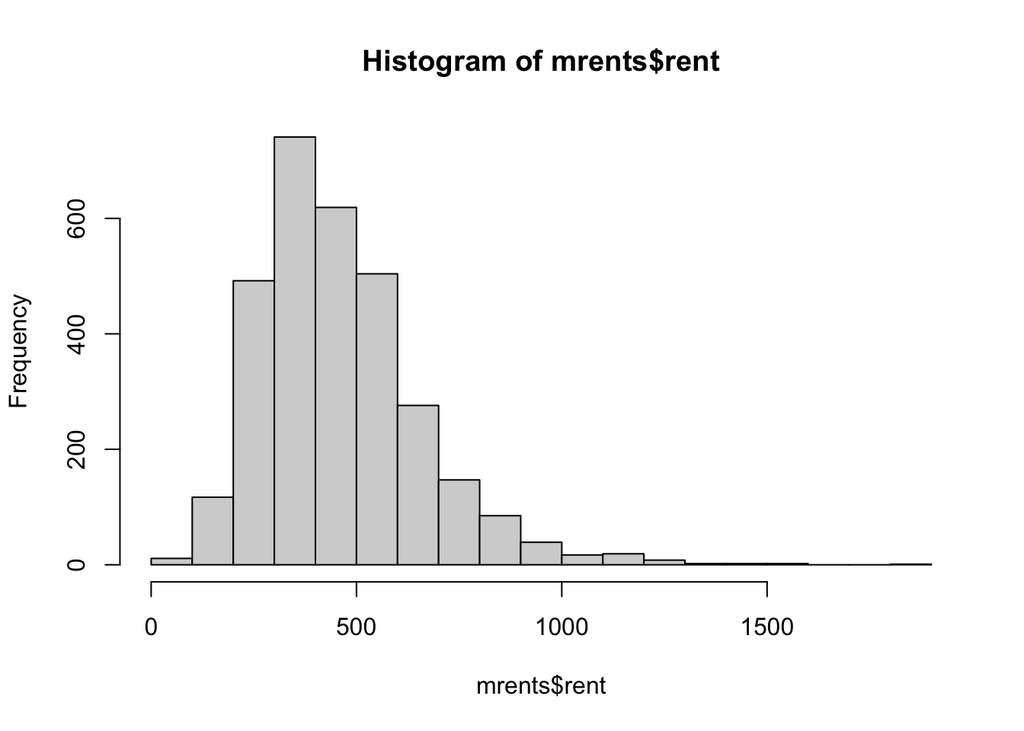

```r
# ?
hist(mrents$rent)
```

Notiamo come la variabile sia abbastanza asimmetrica con una coda abbastanza lunga a destra.

Possiamo calcolare (e visualizzare su un grafico) alcune caratteristiche della variabile:

```r
# ?
mean(mrents$rent)
```

```
## [1] 459.4372
```

```r
# ?
median(mrents$rent)
```

```
## [1] 426.9743
```

```r
# ?
quantile(mrents$rent)
```

```
##         0%        25%        50%        75%       100%
##   40.51282  322.02563  426.97435  559.35899 1843.38464
```

Per visualizzare invece le caratteristiche di variabili categoriali possiamo usare dei barplot:

```r
#?barplot
```

Ora indagare quali siano i fattori che influenzano il prezzo di affitto di una proprietà. Per esempio si possono confrontare alcune caratteristiche degli affitti per diversi tipi di cucina:

```r
# summary
# how to subset in R? use []
```

Usando dei boxplot si possono confrontare visualmente gli affitti in proprietà con cucine o bagni standard e premium:

```r
#?boxplot
```

Possiamo migliorare la leggibilità di questi grafici notando che sebbene `kitchen` sia codificata come variabile numerica nel dataset, essa sia in realtà una variabile categoriale:

```r
#
```

Qual è invece l’effetto della `location`?

```r
# boxplot
```

I boxplots risultano utili per confrontare variabili continue per diversi livelli di variabili categoriali. Spesso però il nostro interesse è nella relazione tra due o più variabili continue. Per esempio potremmo voler indagare l’effetto che ha l’area di un immobile sul prezzo d’affitto. Per visualizzare questa relazione possiamo usare un grafico di dispersione:

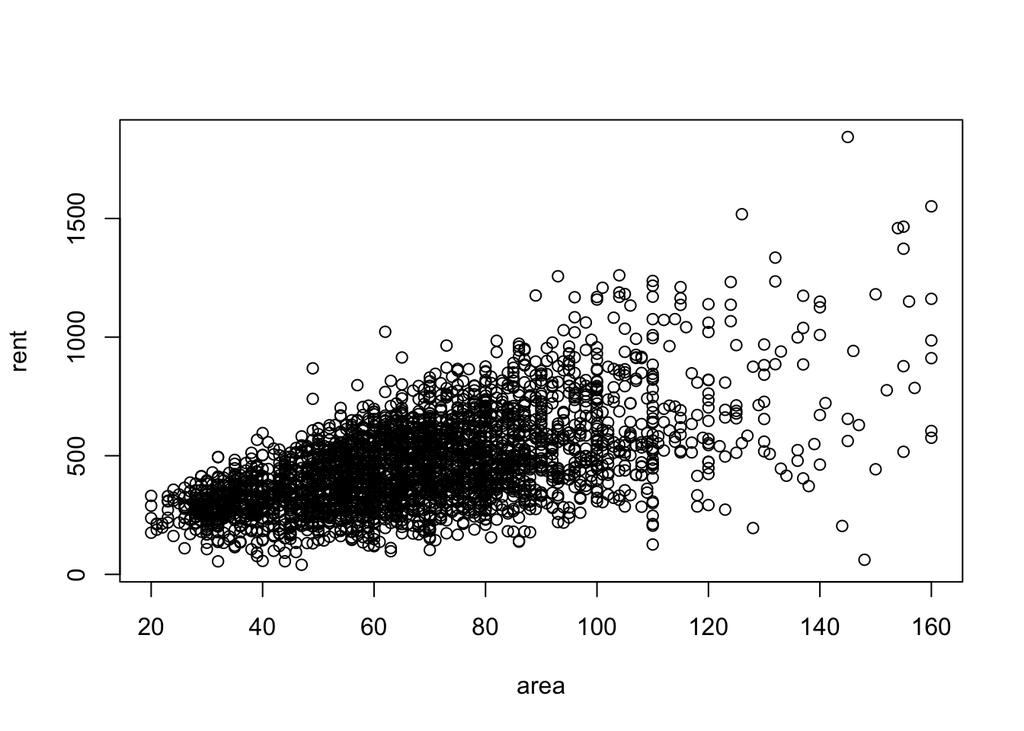

```r
#?
plot(rent ~ area, data = mrents)
```

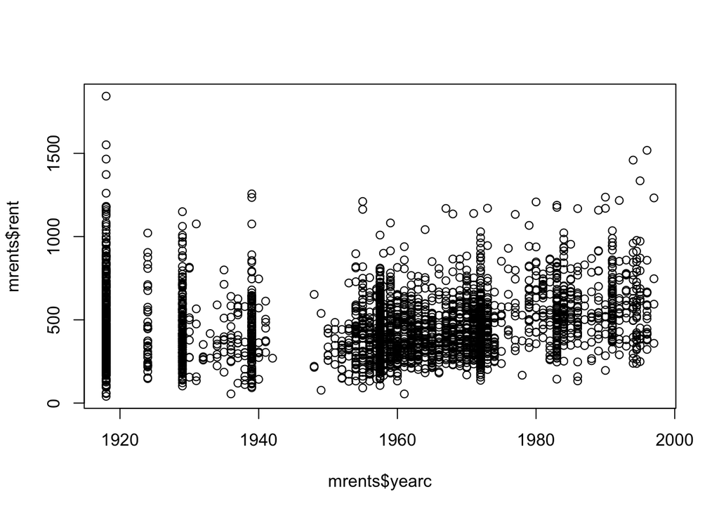

```r
plot(mrents$yearc, mrents$rent)
```

# 2 Predittori ottimali e regressione

Prendiamo in considerazione il dataset `cars` già a disposizione in R:

```r
data(cars)
```

Possiamo avere più dettagli sul dataset leggendo l’help-file a disposizione in R:

```r
help(cars)
```

Diamo un primo sguardo alle caratteristiche del file:

```r
summary(cars)
```

```
##      speed           dist
##  Min.   : 4.0   Min.   :  2.00
##  1st Qu.:12.0   1st Qu.: 26.00
##  Median :15.0   Median : 36.00
##  Mean   :15.4   Mean   : 42.98
##  3rd Qu.:19.0   3rd Qu.: 56.00
##  Max.   :25.0   Max.   :120.00
```

Vediamo che il dataset è composto da due variabili numeriche: `speed` prende valori tra 4 (mph) and 25 (mph) e `dist` prende valori tra 2 and 120 ft. Abbiamo in totale 50 osservazioni.

Possiamo osservare la relazione tra le due variabili con un grafico di dispersione:

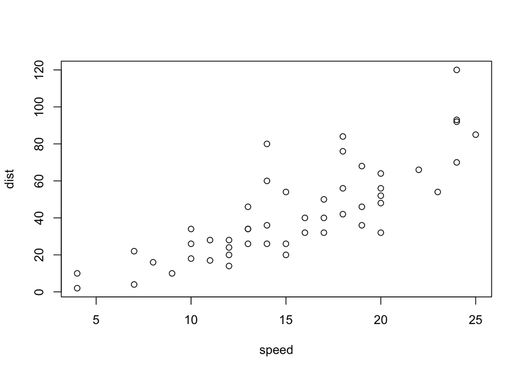

```r
plot(cars) # notice the axis labels
```

La relazione tra le due variabili è positiva: macchine che viaggiano a velocità più alte necessitano di più spazio per fermarsi. Il coefficiente di correlazione (di Pearson) è 0.81: un valore piuttosto alto.

Vogliamo ora stimare una retta di regressione che spieghi `dist` (Y) in funzione di `speed` (X). Dobbiamo quindi assumere che la relazione tra $X$ e $Y$ sia lineare: $Y = b_0 + b_1 X$. Troveremo poi delle stime per $b_0$ e $b_1$ usando le osservazioni campionarie. Nello specifico stimeremo $b_0$ e $b_1$ in modo che la somma dei quadrati tra i valori osservati ($y_i$) e i valori stimati ($\hat{y}_i$) sia la più piccola possibile. Desideriamo quindi minimizzare (in funzione di $b_0$ e $b_1$) la seguente quantità:
$$SumSq(b_0,b_1) = \sum_{i=1}^n{ (y_i - (b_0 +
b_1{x}_i))^2 }.$$

Per valori arbitrari di $b_0$ e $b_1$ si può osservare la retta specificata dai valori e calcolare il valore di $SumSq(b_0,b_1)$

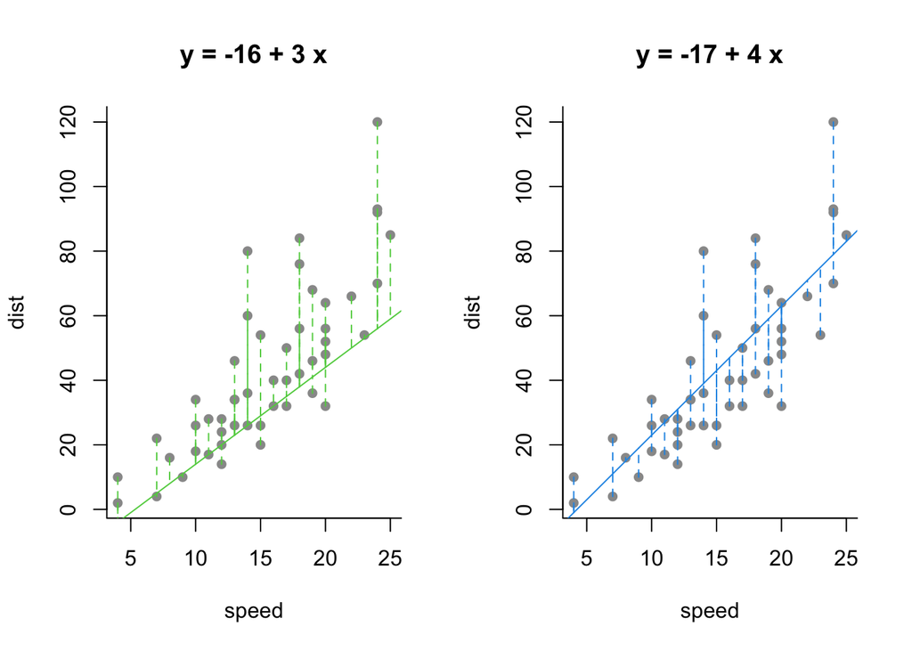

```r
par(mfrow=c(1,2), bty = "l") ## see ?par
plot(cars, pch = 16, col = "grey60")
b0_1 <- -16; b1_1 <- 3
abline(b0_1, b1_1, col = 3)
segments(cars$speed, y0 = cars$dist,
         y1 = b0_1 + b1_1 * cars$speed,
         lty = 2, col = 3)
title(main=paste("y =",b0_1,"+",b1_1,"x"))
plot(cars, pch = 16, col = "grey60")
b0_2 <- -17; b1_2 <- 4
abline(b0_2, b1_2, col = 4)
segments(cars$speed, y0 = cars$dist,
         y1 = b0_2 + b1_2 * cars$speed,
         lty = 2, col = 4)
title(main=paste("y =",b0_2,"+",b1_2,"x"))
```

Scriviamo ora una funzione che calcoli $SumSq(b_0,b_1)$:

```r
computeSumSquares <- function(bs, y, x){

}
# computeSumSquares(c(b0_1, b1_1), y = cars$dist,  x = cars$speed)
# computeSumSquares(c(b0_2, b1_2), y = cars$dist,  x = cars$speed)
# computeSumSquares(c(b0_2, b1_2+0.2), y = cars$dist,  x = cars$speed)
# computeSumSquares(c(b0_2+1, b1_2), y = cars$dist,  x = cars$speed)
```

Si noti come i dati del campione $(x,y)$ non cambiano.

Calcoliamo per esempio la funzione per una griglia di possibili valori di $b_0$ e $b_1$:

```r
b0seq <- seq(-20,-5, length.out = 7)
b1seq <- seq(3.4,4.6,length.out = 9)
ssqseq <- matrix(NA, ncol = 9, nrow= 7)
```

La funzione dipende da entrambi i parametri: possiamo fare diversi grafici in 2-D o usare `persp` per fare un grafico in 3D in R:

```r
# par(mfrow=c(1,2))
# plot(b0seq,ssqseq[,1], type = "l", ylim = range(ssqseq))
# lines(b0seq,ssqseq[,3], col = 2)
# lines(b0seq,ssqseq[,5], col = 3)
# lines(b0seq,ssqseq[,7], col = 4)
# lines(b0seq,ssqseq[,9], col = 5)
# legend("topright", col=c(1,2,3,4,5), legend = paste("b1 =",b1seq[c(1,3,5,7,9)]), lty = 1)
# plot(b1seq,ssqseq[1,], type = "l", ylim = range(ssqseq))
# lines(b1seq,ssqseq[3,], col = 2)
# lines(b1seq,ssqseq[5,], col = 3)
# lines(b1seq,ssqseq[7,], col = 4)
# legend("topright", col=c(1,2,3,4), legend = paste("b0 =",b0seq[c(1,3,5,7)]), lty = 1)
```

```r
# image(b0seq,b1seq,ssqseq)
# par(mfrow=c(1,2))
# persp(b0seq,b1seq,ssqseq, ticktype = "detailed")
# persp(b1seq,b0seq,t(ssqseq), ticktype = "detailed")
# which(ssqseq == min(ssqseq), arr.ind = TRUE)
```

Desideriamo individuare il valori ($b_0$,$b_1$) che minimizzano SumSq($b_0$,$b_1$). Potremmo usare un ottimizzatone numerico, ma in questo caso è possible trovare una soluzione analitica al problema che risulta essere:
$$\hat{\beta}_1 = \frac{c_{XY}}{s^2_{X}} = r_{XY}
\frac{s_{Y}}{s_{X}},\quad \mbox{and} \quad \hat{\beta}_0 =
\overline{y}-\hat{\beta}_1 \overline{x}$$

```r
# rxy <-
# sx <-
# mx <-
# my <-
# beta1_hat <-
# beta0_hat <-
```

Fissiamo $b_0$ - e guardiamo come cambia la somma dei quadrati in funzione di $b_1$:

```r
#
```

In R tipicamente non faremmo questi conti passo passo, ma possiamo direttamente usare la funzione `lm` che stima modelli di regressione che minimizzano la somma dei quadrati:

```r
# Italian keyboard: to do ~ press Alt+0126
lm(dist ~ speed, data = cars)
```

```
##
## Call:
## lm(formula = dist ~ speed, data = cars)
##
## Coefficients:
## (Intercept)        speed
##     -17.579        3.932
```

Possiamo vedere quali sono i valori stimati per i coefficienti di regressione usando la funzione `coef`

```r
fit <- lm(dist ~ speed, data = cars)
coef(fit)
```

```
## (Intercept)       speed
##  -17.579095    3.932409
```

Possiamo infine ottenere molte informazioni sulla stima ottenuta usando la funzione `summary`, che, quando applicata ad un oggetto di classe `lm` fornisce come output molte informazioni sulla stima ottenuta:

```r
summary(fit)
```

```
##
## Call:
## lm(formula = dist ~ speed, data = cars)
##
## Residuals:
##     Min      1Q  Median      3Q     Max
## -29.069  -9.525  -2.272   9.215  43.201
##
## Coefficients:
##             Estimate Std. Error t value Pr(>|t|)
## (Intercept) -17.5791     6.7584  -2.601   0.0123 *
## speed         3.9324     0.4155   9.464 1.49e-12 ***
## ---
## Signif. codes:  0 '***' 0.001 '**' 0.01 '*' 0.05 '.' 0.1 ' ' 1
##
## Residual standard error: 15.38 on 48 degrees of freedom
## Multiple R-squared:  0.6511, Adjusted R-squared:  0.6438
## F-statistic: 89.57 on 1 and 48 DF,  p-value: 1.49e-12
```

Vedremo nel corso delle prossime lezioni più dettagli sui vari componenti dell’output.

Per calcolare $\hat{y}_i$ possiamo valutare la funzione $\beta_0 + \beta_1 x_i$:

```r
#
# also see ?fitted
```

La stima di $\sigma$ quindi è:

```r
# sqrt()
```